# Forecast daily bike rental demand using time series models

Samuel Akuffo

2025-08-08

# About Data Analysis Report

This RMarkdown file contains the report of the data analysis done for the project on forecasting daily bike rental demand using time series models in R. It contains analysis such as data exploration, summary statistics and building the time series models. The final report was completed on Sat Aug 9 22:13:17 2025.

**Data Description:**

This dataset contains the daily count of rental bike transactions between years 2011 and 2012 in Capital bikeshare system with the corresponding weather and seasonal information.

**Data Source:** https://archive.ics.uci.edu/ml/datasets/bike+sharing+dataset

**Relevant Paper:**

Fanaee-T, Hadi, and Gama, Joao, ‘Event labeling combining ensemble detectors and background knowledge’, Progress in Artificial Intelligence (2013): pp. 1-15, Springer Berlin Heidelberg

# Loading and exploring the data

```r
## Import required packages

## Load data and install packages
if(!require(tidyverse)) install.packages("tidyverse")
if(!require(lubridate)) install.packages("lubridate")
if(!require(timetk)) install.packages("timetk")
if(!require(forecast)) install.packages("forecast")
if(!require(tseries)) install.packages("tseries")
if(!require(zoo)) install.packages("zoo")
```

```r
if(!require(ggplot2)) install.packages("ggplot2")

library(tidyverse)
library(lubridate)
library(timetk)
library(forecast)
library(tseries)
library(zoo)
library(ggplot2)

url <- "C:/Users/samaw/projects/bikeshare/day.csv"
bike_data <- read.csv(url)
head(bike_data)
```

```
##   instant     dteday season yr mnth holiday weekday workingday weathersit
## 1       1 2011-01-01      1  0    1       0       6          0          2
## 2       2 2011-01-02      1  0    1       0       0          0          2
## 3       3 2011-01-03      1  0    1       0       1          1          1
## 4       4 2011-01-04      1  0    1       0       2          1          1
## 5       5 2011-01-05      1  0    1       0       3          1          1
## 6       6 2011-01-06      1  0    1       0       4          1          1
##       temp    atemp      hum windspeed casual registered  cnt
## 1 0.344167 0.363625 0.805833 0.1604460    331        654  985
## 2 0.363478 0.353739 0.696087 0.2485390    131        670  801
## 3 0.196364 0.189405 0.437273 0.2483090    120       1229 1349
## 4 0.200000 0.212122 0.590435 0.1602960    108       1454 1562
## 5 0.226957 0.229270 0.436957 0.1869000     82       1518 1600
## 6 0.204348 0.233209 0.518261 0.0895652     88       1518 1606
```

```r
glimpse(bike_data)
```

```
## Rows: 731
## Columns: 16
## $ instant    <int> 1, 2, 3, 4, 5, 6, 7, 8, 9, 10, 11, 12, 13, 14, 15, 16, 17, …
## $ dteday     <chr> "2011-01-01", "2011-01-02", "2011-01-03", "2011-01-04", "20…
## $ season     <int> 1, 1, 1, 1, 1, 1, 1, 1, 1, 1, 1, 1, 1, 1, 1, 1, 1, 1, 1, 1,…
## $ yr         <int> 0, 0, 0, 0, 0, 0, 0, 0, 0, 0, 0, 0, 0, 0, 0, 0, 0, 0, 0, 0,…
## $ mnth       <int> 1, 1, 1, 1, 1, 1, 1, 1, 1, 1, 1, 1, 1, 1, 1, 1, 1, 1, 1, 1,…
## $ holiday    <int> 0, 0, 0, 0, 0, 0, 0, 0, 0, 0, 0, 0, 0, 0, 0, 0, 1, 0, 0, 0,…
## $ weekday    <int> 6, 0, 1, 2, 3, 4, 5, 6, 0, 1, 2, 3, 4, 5, 6, 0, 1, 2, 3, 4,…
## $ workingday <int> 0, 0, 1, 1, 1, 1, 1, 0, 0, 1, 1, 1, 1, 1, 0, 0, 0, 1, 1, 1,…
## $ weathersit <int> 2, 2, 1, 1, 1, 1, 2, 2, 1, 1, 2, 1, 1, 1, 2, 1, 2, 2, 2, 2,…
## $ temp       <dbl> 0.3441670, 0.3634780, 0.1963640, 0.2000000, 0.2269570, 0.20…
## $ atemp      <dbl> 0.3636250, 0.3537390, 0.1894050, 0.2121220, 0.2292700, 0.23…
## $ hum        <dbl> 0.805833, 0.696087, 0.437273, 0.590435, 0.436957, 0.518261,…
## $ windspeed  <dbl> 0.1604460, 0.2485390, 0.2483090, 0.1602960, 0.1869000, 0.08…
## $ casual     <int> 331, 131, 120, 108, 82, 88, 148, 68, 54, 41, 43, 25, 38, 54…
## $ registered <int> 654, 670, 1229, 1454, 1518, 1518, 1362, 891, 768, 1280, 122…
## $ cnt        <int> 985, 801, 1349, 1562, 1600, 1606, 1510, 959, 822, 1321, 126…
```

```r
summary(bike_data)
```

```
##     instant         dteday              season            yr
##  Min.   :  1.0   Length:731         Min.   :1.000   Min.   :0.0000
##  1st Qu.:183.5   Class :character   1st Qu.:2.000   1st Qu.:0.0000
##  Median :366.0   Mode  :character   Median :3.000   Median :1.0000
##  Mean   :366.0                      Mean   :2.497   Mean   :0.5007
##  3rd Qu.:548.5                      3rd Qu.:3.000   3rd Qu.:1.0000
##  Max.   :731.0                      Max.   :4.000   Max.   :1.0000
##       mnth          holiday           weekday        workingday
##  Min.   : 1.00   Min.   :0.00000   Min.   :0.000   Min.   :0.000
##  1st Qu.: 4.00   1st Qu.:0.00000   1st Qu.:1.000   1st Qu.:0.000
##  Median : 7.00   Median :0.00000   Median :3.000   Median :1.000
##  Mean   : 6.52   Mean   :0.02873   Mean   :2.997   Mean   :0.684
##  3rd Qu.:10.00   3rd Qu.:0.00000   3rd Qu.:5.000   3rd Qu.:1.000
##  Max.   :12.00   Max.   :1.00000   Max.   :6.000   Max.   :1.000
##    weathersit         temp             atemp              hum
##  Min.   :1.000   Min.   :0.05913   Min.   :0.07907   Min.   :0.0000
##  1st Qu.:1.000   1st Qu.:0.33708   1st Qu.:0.33784   1st Qu.:0.5200
##  Median :1.000   Median :0.49833   Median :0.48673   Median :0.6267
##  Mean   :1.395   Mean   :0.49538   Mean   :0.47435   Mean   :0.6279
##  3rd Qu.:2.000   3rd Qu.:0.65542   3rd Qu.:0.60860   3rd Qu.:0.7302
##  Max.   :3.000   Max.   :0.86167   Max.   :0.84090   Max.   :0.9725
##    windspeed           casual         registered        cnt
##  Min.   :0.02239   Min.   :   2.0   Min.   :  20   Min.   :  22
##  1st Qu.:0.13495   1st Qu.: 315.5   1st Qu.:2497   1st Qu.:3152
##  Median :0.18097   Median : 713.0   Median :3662   Median :4548
##  Mean   :0.19049   Mean   : 848.2   Mean   :3656   Mean   :4504
##  3rd Qu.:0.23321   3rd Qu.:1096.0   3rd Qu.:4776   3rd Qu.:5956
##  Max.   :0.50746   Max.   :3410.0   Max.   :6946   Max.   :8714
```

## Describing and exploring the data

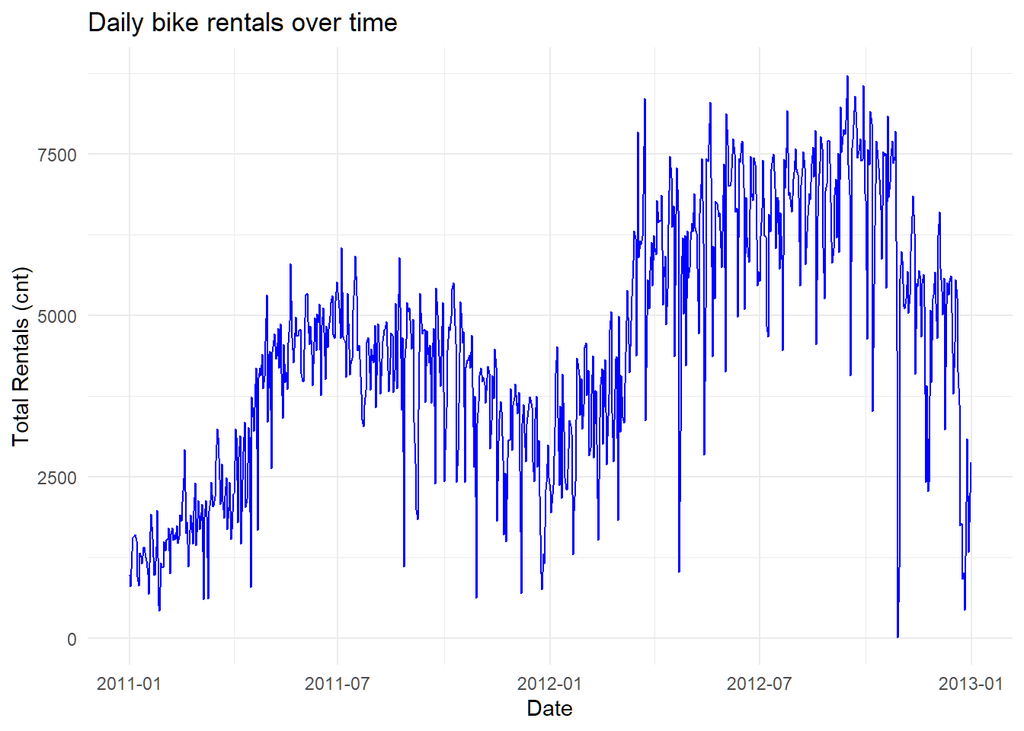

```r
bike_data$dteday <- ymd(bike_data$dteday)

# Plot of daily rentals over time
ggplot(bike_data, aes(x = dteday, y=cnt)) +
    geom_line(color="blue") +
    labs(title="Daily bike rentals over time", x="Date", y="Total Rentals (cnt)") +
    theme_minimal()
```

```r
#Summary statistics for rentals
mean_rentals <- mean(bike_data$cnt)
median_rentals <- median(bike_data$cnt)
max_rentals <- max(bike_data$cnt)
min_rentals <- min(bike_data$cnt)

cat("Mean rentals:", mean_rentals, "\n")
```

```
## Mean rentals: 4504.349
```

```r
cat("Median rentals", median_rentals, "\n")
```

```
## Median rentals 4548
```

```r
cat("Max rentals", max_rentals, "\n")
```

```
## Max rentals 8714
```

```r
cat("Min rentals", min_rentals, "\n")
```

```
## Min rentals 22
```

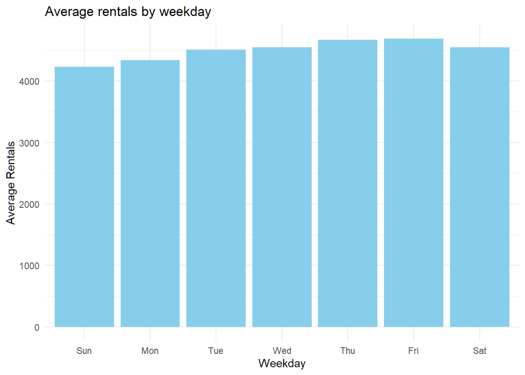

```r
#Bike rentals by weekday to show weekly seasonality
bike_data %>%
    mutate(weekday = wday(dteday, label=TRUE)) %>%
    group_by(weekday) %>%
    summarise(avg_rentals = mean(cnt)) %>%
    ggplot(aes(x=weekday, y=avg_rentals)) +
    geom_bar(stat="identity",fill="skyblue") +
    labs(title="Average rentals by weekday",
         x="Weekday", y="Average Rentals") +
    theme_minimal()
```

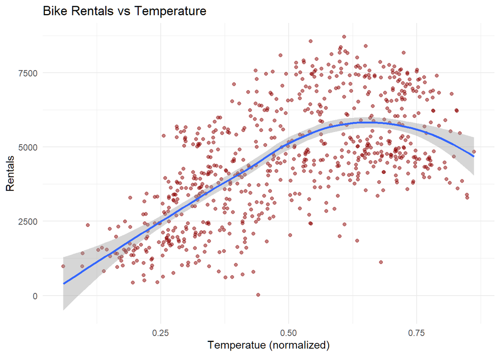

```r
# Rentals vs Temperature
ggplot(bike_data, aes(x=temp, y=cnt)) +
  geom_point(alpha=0.5, color="darkred") +
  geom_smooth(method="loess") +
  labs(title="Bike Rentals vs Temperature", x="Temperatue (normalized)", y="Rentals") +
  theme_minimal()
```

## Interactive time series plots

```r
## Read about the timetk package
ts_data <- bike_data %>%
  select(dteday, cnt) %>%
  tk_ts(start = c(2011, 1), frequency = 365)
```

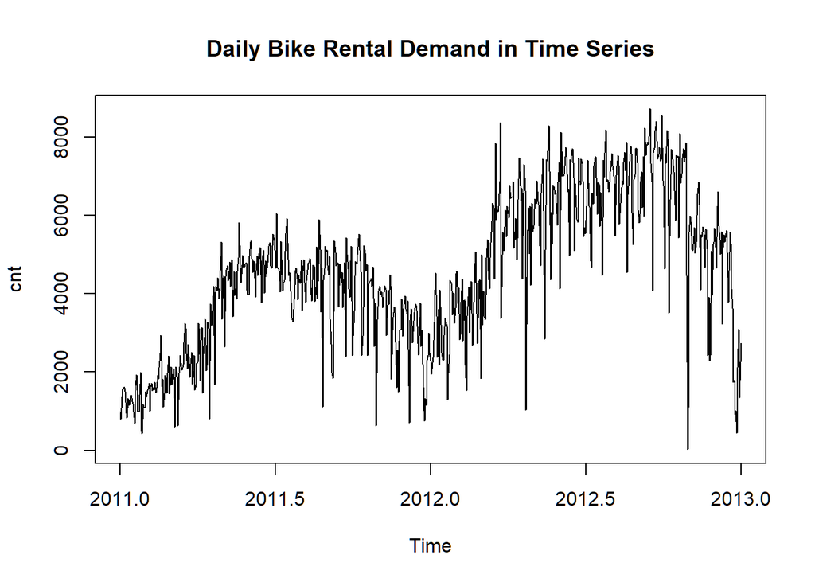

```r
plot(ts_data, main = "Daily Bike Rental Demand in Time Series")
```

## Smoothing of time series data

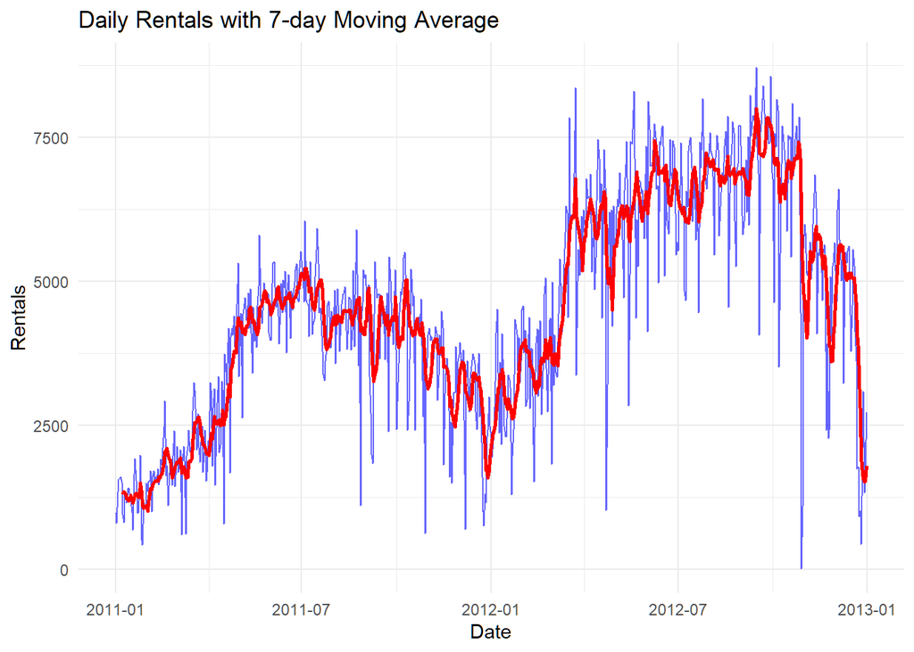

```r
# 7 Day Moving Average to smooth data
bike_data <- bike_data %>%
    arrange(dteday) %>%
    mutate(ma_7day = zoo::rollmean(cnt, k=7, fill=NA, align="right"))

#Plot of original and smoothed rentals
ggplot(bike_data, aes(x=dteday)) +
    geom_line(aes(y=cnt), color="blue", alpha=0.6) +
    geom_line(aes(y=ma_7day), color="red", size=1) +
    labs(title="Daily Rentals with 7-day Moving Average", x="Date", y="Rentals") +
    theme_minimal()
```

## Decompsing and accessing the stationarity of time series data

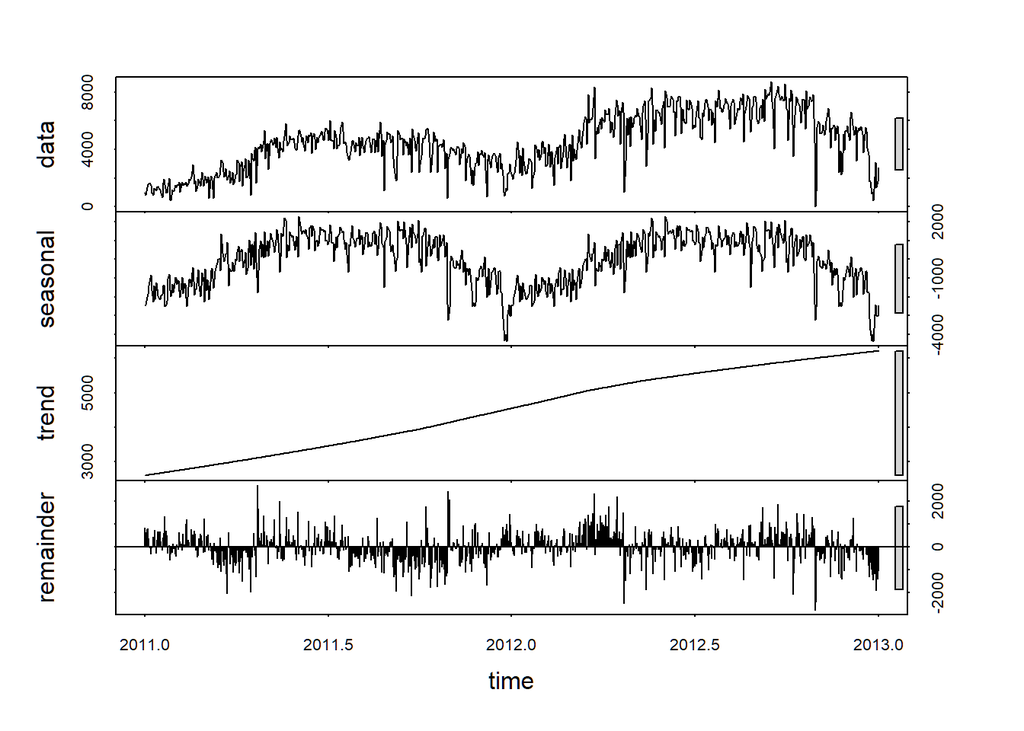

```r
rentals_ts <- ts(bike_data$cnt, start=c(2011, 1), frequency=365)

ts_decomp <- stl(rentals_ts, s.window="periodic")
plot(ts_decomp)
```

```r
#Dicky-Fuller test for stationarity
adf_test <- adf.test(rentals_ts)
adf_test
```

```
##
##  Augmented Dickey-Fuller Test
##
## data:  rentals_ts
## Dickey-Fuller = -1.6351, Lag order = 9, p-value = 0.7327
## alternative hypothesis: stationary
```

```r
if (adf_test$p.value > 0.05) {
  rentals_ts <- diff(rentals_ts)
}

rentals_ts <- na.omit(rentals_ts)
```

## Fitting and forecasting time series data using ARIMA models

```r
#Auto ARIMA model fitting
fit_auto <- auto.arima(rentals_ts)

summary(fit_auto)
```

```
## Series: rentals_ts
## ARIMA(1,0,1) with zero mean
##
## Coefficients:
##          ar1      ma1
##       0.3584  -0.8896
## s.e.  0.0423   0.0192
##
## sigma^2 = 857769:  log likelihood = -6021.96
## AIC=12049.91   AICc=12049.94   BIC=12063.69
##
## Training set error measures:
##                    ME     RMSE      MAE      MPE    MAPE      MASE       ACF1
## Training set 12.89471 924.8887 648.5267 164.5701 245.294 0.5930705 0.01116795
```

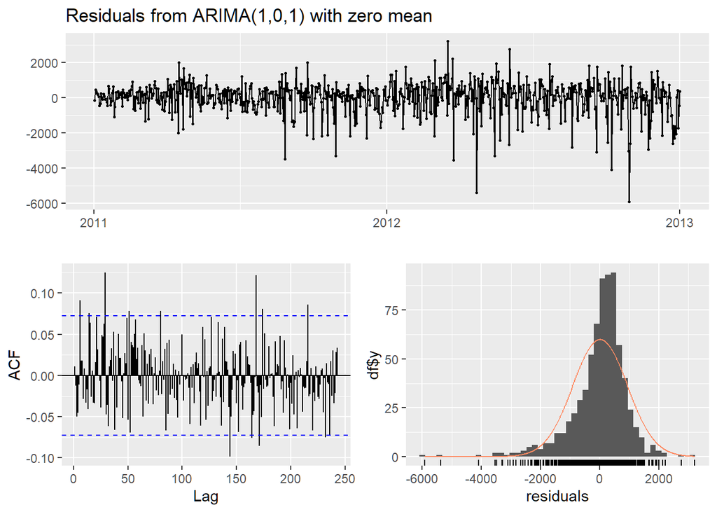

```
##
##  Ljung-Box test
##
## data:  Residuals from ARIMA(1,0,1) with zero mean
## Q* = 176.93, df = 144, p-value = 0.03227
##
## Model df: 2.   Total lags used: 146
```

```r
#Checking residuals diagnostics(fit_auto)
checkresiduals(fit_auto)
```

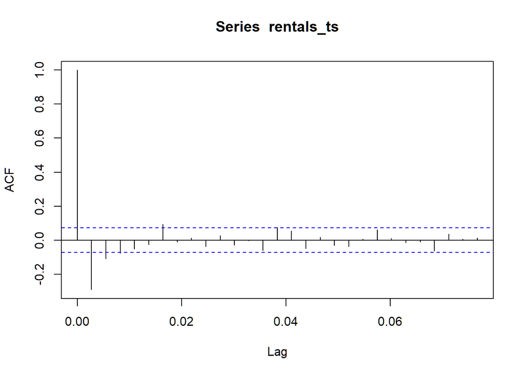

```r
# Inspect ACF/PACF for manual choice
acf(rentals_ts)
```

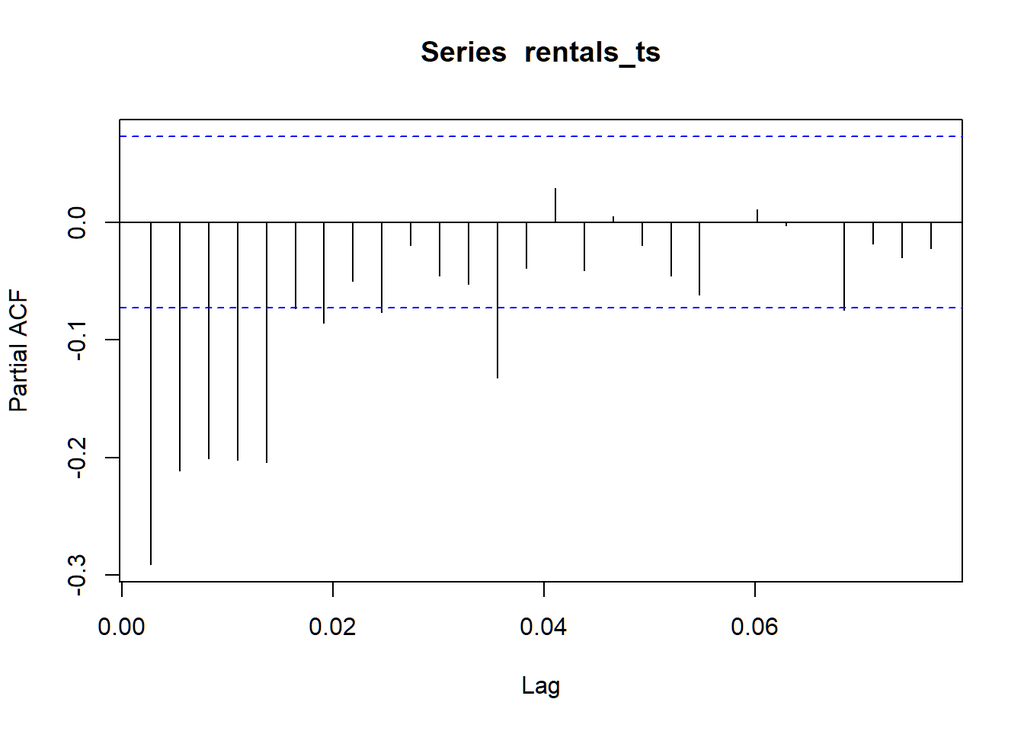

```r
pacf(rentals_ts)
```

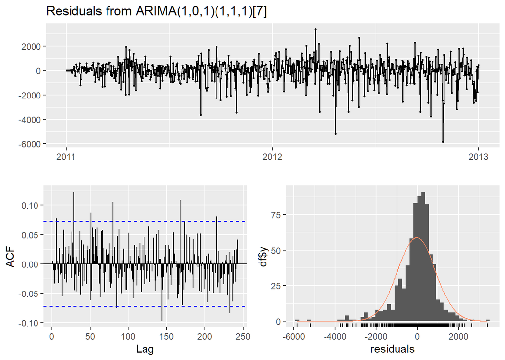

```
##
##  Ljung-Box test
##
## data:  Residuals from ARIMA(1,0,1)(1,1,1)[7]
## Q* = 157.25, df = 142, p-value = 0.1804
##
## Model df: 4.   Total lags used: 146
```

```r
fit_manual <- tryCatch({
  Arima(
    rentals_ts,
    order = c(1,0,1),
    seasonal = list(order = c(1,1,1), period = 7) # safer for convergence
  )
}, error = function(e) {
  message("Manual ARIMA failed: ", e$message)
  NULL
})

if (!is.null(fit_manual)) {
  summary(fit_manual)
  checkresiduals(fit_manual)
}
```